# Valeurs extrêmes I

Olivier Berthier

2024-07-31

L’objet de ce rapport consiste à étudier un jeu de données métérologique concernant la ville de Fort Collins (Colorado, USA) selon la théorie des valeur extrêmes.

```r
data (FCwx)
str (FCwx)
```

```
## 'data.frame':    36524 obs. of  8 variables:
##  $ Year: int  1900 1900 1900 1900 1900 1900 1900 1900 1900 1900 ...
##  $ Mn  : int  1 1 1 1 1 1 1 1 1 1 ...
##  $ Dy  : int  1 2 3 4 5 6 7 8 9 10 ...
##  $ MxT : int  39 43 55 50 50 52 50 48 47 48 ...
##  $ MnT : int  10 9 23 24 16 10 14 9 25 10 ...
##  $ Prec: num  0 0 0 0 0 0 0 0 0 0 ...
##  $ Snow: num  0 0 0 0 0 0 0 0 0 0 ...
##  $ SnCv: num  NA NA NA NA NA NA NA NA NA NA ...
```

# Temperatures maximales

Nous commencerons par étudier la variable **MxT** qui correspond au maximum observé chaque jour à Fort Collins sur une période de cent ans (1900 à 1999), soit 36524 observations. L’unité est le degré Fahrenheit.

Par commodité, nous créons un nouveau dataframe **fc** qui ne retient que notre variable d’intérêt (renommée **max**) et les trois variables de date.

```
##    Min. 1st Qu.  Median    Mean 3rd Qu.    Max.
##   -10.0    49.0    64.0    62.4    78.0   102.0
```

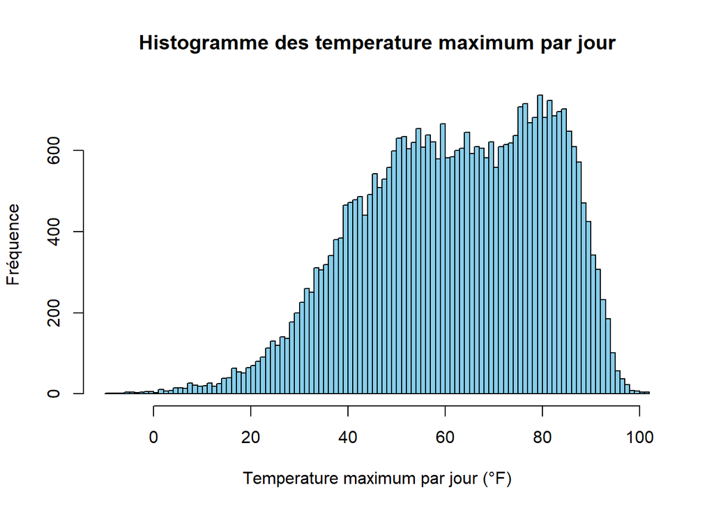

La distribution ressemble assez à une loi bimodale. La queue à droite est plus courte qu’à gauche (asymétrie négative ou *skewness négative* confirmée par une médiane supérieure à la moyenne).  
A droite, le coté qui nous intéresse, la queue est courte (la fréquence des valeurs décroit très rapidement). Le *summary* indique que la médiane (64°F) est nettement plus proche de la valeur max (102°F) que de la valeur min (-10°F)

Affichons tous les points de manière chronologique:

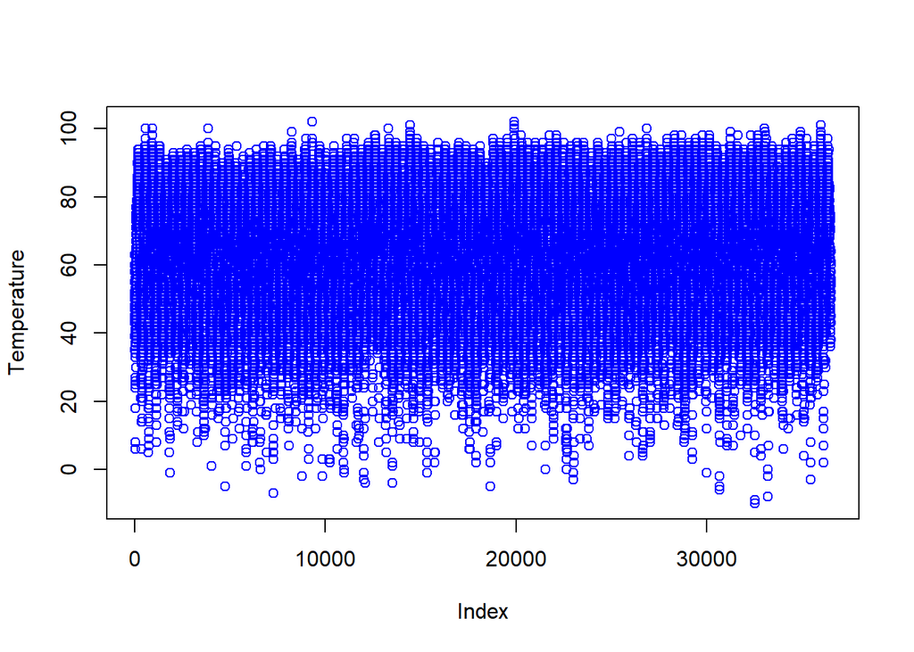

Le graphique confirme bien que la variance dans les grandes valeurs est beaucoup plus faible que dans les petites

## Loi des valeurs extrêmes généralisées (GEV)

Retenons uniquement la valeur maximale de chaque année dans le dataframe **mpa** (maximum par année):

```r
maxpa<- blockmaxxer(fc, blocks = fc$Year, which="max")
summary (maxpa$max)
```

```
##    Min. 1st Qu.  Median    Mean 3rd Qu.    Max.
##   90.00   94.00   96.00   95.92   97.25  102.00
```

Les 100 valeurs maximales retenues s’étalent de 90 à 102°F.

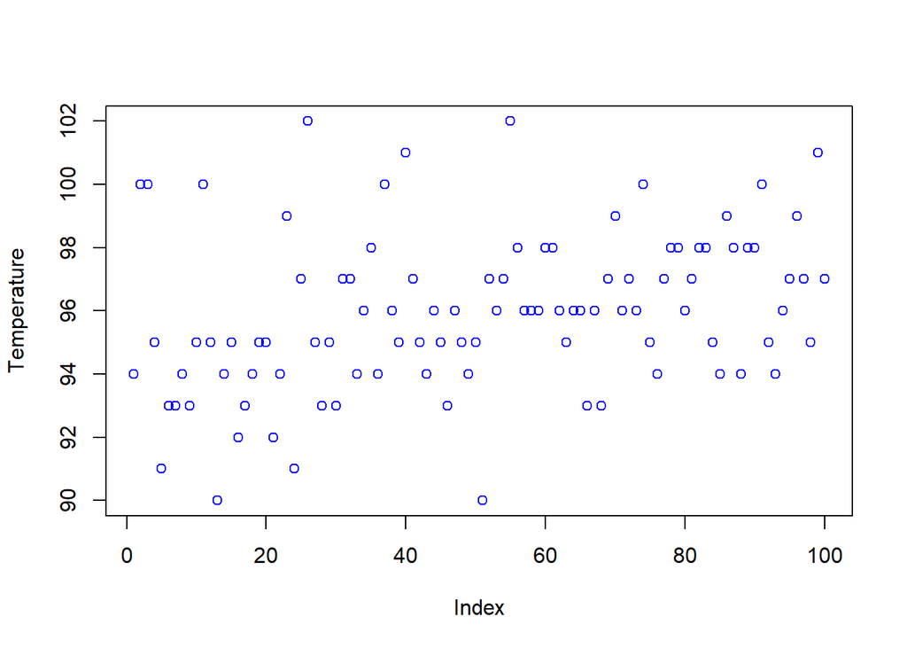

La répartition n’indique pas d’évolution notable des valeurs max annuelles au cours du temps (stationnarité et indépendance respectées).

### Modélisation par méthode du maximum de vraisemblance (MLE)

100 observations est un nombre suffisant pour appliquer la méthode *MLE*.

```r
Fit_max_GEV_MLE <- fevd(maxpa$max,type="GEV",method="MLE")
Fit_max_GEV_MLE
```

```
##
## fevd(x = maxpa$max, type = "GEV", method = "MLE")
##
## [1] "Estimation Method used: MLE"
##
##
##  Negative Log-Likelihood Value:  232.3781
##
##
##  Estimated parameters:
##   location      scale      shape
## 95.0024825  2.4240403 -0.2417402
##
##  Standard Error Estimates:
##   location      scale      shape
## 0.26660820 0.18442789 0.06137203
##
##  Estimated parameter covariance matrix.
##              location        scale        shape
## location  0.071079933  0.002717032 -0.006023777
## scale     0.002717032  0.034013645 -0.005818578
## shape    -0.006023777 -0.005818578  0.003766527
##
##  AIC = 470.7562
##
##  BIC = 478.5717
```

le $\gamma$, *shpae* ici, est négatif (-0.2417402), ce qui nous place dans le domaine d’attraction de *Weibull* (point terminal fini, donc).  
Au vu de la distribution des températures dans notre jeu de données initial, Nous pouvions nous attendre au domaine de *Weibull* (queue courte).

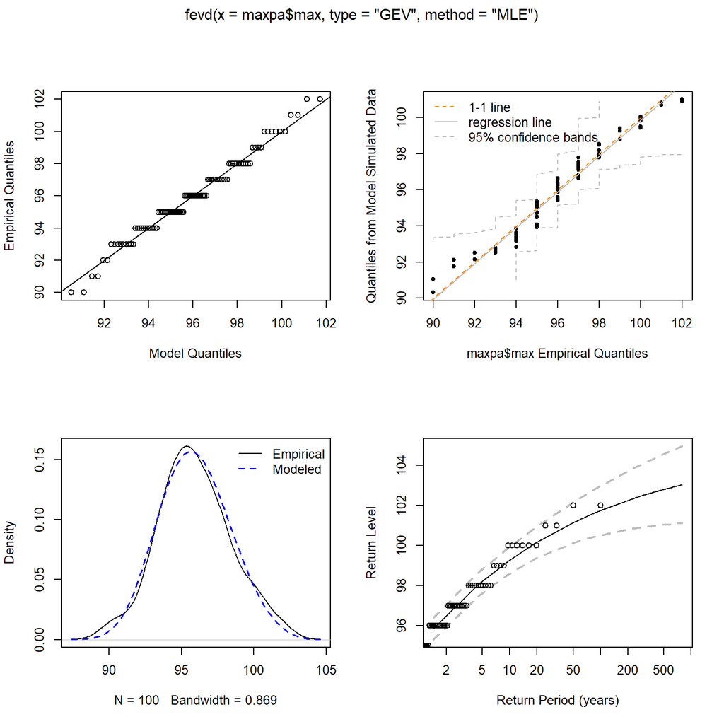

On observe que les valeurs se répartissent par “paquets”, ceci est dû au nombre restreint de valeurs que peuvent prendre les observations (l’étendue est de 12°F, les températures étant ici des nombres entiers, cela correspond seulement à 13 valeurs possibles).

Graphique 1 et 2: Les points sont bien alignés le long des droites.  
Graphique 3: Les courbes de densité se confondent presque dans la queue de droite, ce qui indique une bonne modélisation des valeurs extrêmes supérieures.  
Graphique 4: (*return level plot*), période de retour en abscisses (échelle logarithmique) et quantiles en ordonnées. les points sont biens dans l’intervalle de confiance. Une légère sous-estimation du phénomène peut être cependant remarquée (les plus grandes valeurs sont au-dessus de la courbe).

Globalement, les quartes graphiques indiquent une bonne modélisation par la MLE.

Intervalle de confiance des paramêtres à 95% et 99%:

```r
ci(Fit_max_GEV_MLE,type="parameter")                   # IC à 95%
```

```
## fevd(x = maxpa$max, type = "GEV", method = "MLE")
##
## [1] "Normal Approx."
##
##          95% lower CI   Estimate 95% upper CI
## location   94.4799401 95.0024825   95.5250250
## scale       2.0625683  2.4240403    2.7855123
## shape      -0.3620272 -0.2417402   -0.1214533
```

```r
ci(Fit_max_GEV_MLE,type="parameter", alpha=0.01)           # IC à 99%
```

```
## fevd(x = maxpa$max, type = "GEV", method = "MLE")
##
## [1] "Normal Approx."
##
##          99% lower CI   Estimate 99% upper CI
## location   94.3157453 95.0024825  95.68921975
## scale       1.9489855  2.4240403   2.89909504
## shape      -0.3998241 -0.2417402  -0.08365636
```

L’intervalle de confiance de $\gamma$ reste négatif, y compris à 99%. Ce qui confirme que la distribution correspond à une loi dans le domaine d’attraction de *Weibull*.

Critique des résultats: le domaine de *Weibull* définit des lois aux points terminaux finis. Cela correspond apparemment à nos données. Cependant, sur le principe, la température maximale atteinte n’est pas une valeur finie (au moins dans cette échelle de valeurs, la température de Planck, d’environ 1.42E32 °K, étant souvent considérée comme une limite théorique supérieure, mais c’est une autre histoire…).  
En ne retenant que ce modèle en première approche, on peut craindre de sous-estimer nos prédictions.  
Aussi, pour vérification, il peut être intéressant de vérifier les résultats obtenus par un modèle utilisant la loi de *Gumbel*.

```r
Fit_max_GEV_MLE_G <- fevd(maxpa$max,  type="Gumbel",method="MLE")
Fit_max_GEV_MLE_G
```

```
##
## fevd(x = maxpa$max, type = "Gumbel", method = "MLE")
##
## [1] "Estimation Method used: MLE"
##
##
##  Negative Log-Likelihood Value:  238.2629
##
##
##  Estimated parameters:
##  location     scale
## 94.697039  2.388193
##
##  Standard Error Estimates:
##  location     scale
## 0.2531359 0.1720035
##
##  Estimated parameter covariance matrix.
##            location      scale
## location 0.06407781 0.01443549
## scale    0.01443549 0.02958521
##
##  AIC = 480.5258
##
##  BIC = 485.7362
```

Les AIC et BIC sont moins bons quand on force une modélisation selon la loi de *Gumbel*.

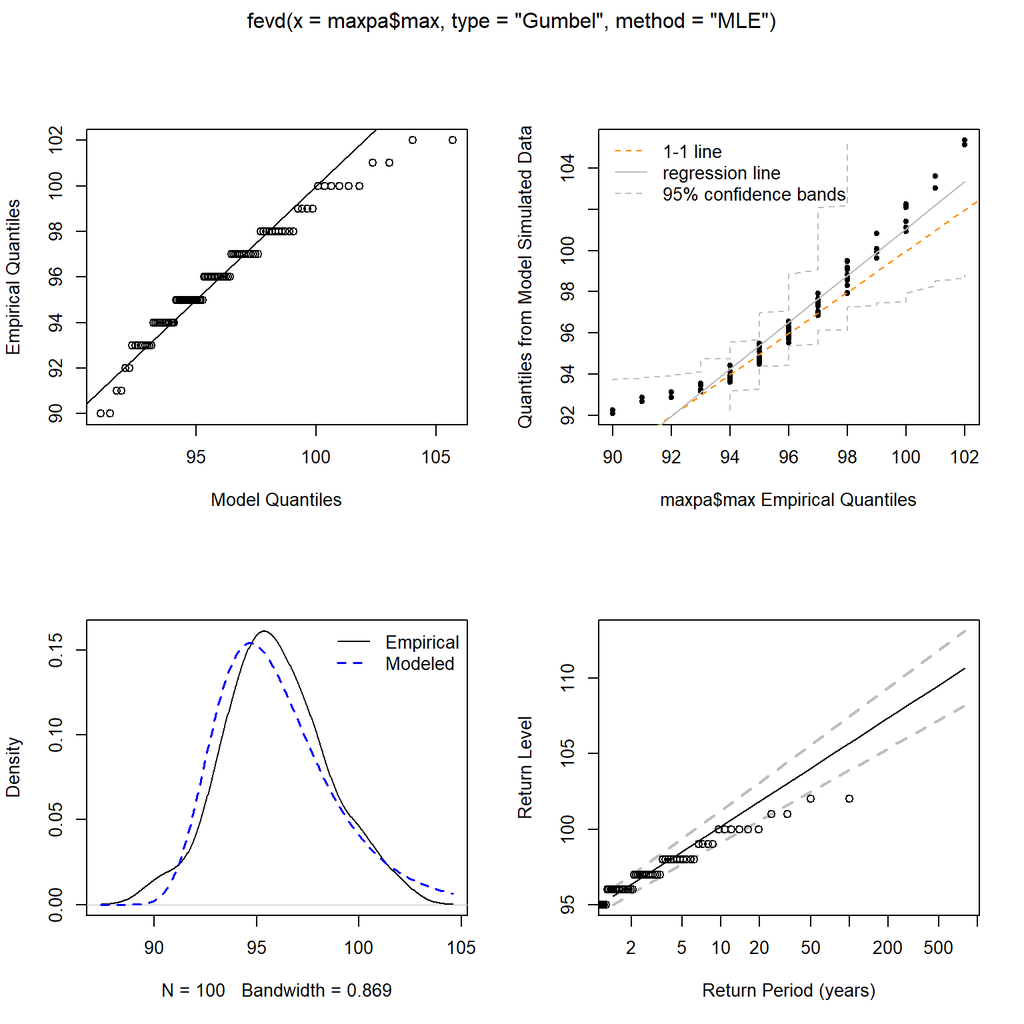

Il apparaît de manière évidente qu’une modélisation *Gumbel* tend à surestimer les valeurs par rapport à la réalité.

La loi de *Weibull* semble bien mieux correspondre à nos données.

### Méthode des moments pondérés (PWM)

Considérée comme mieux adaptée pour une modélisation à partir d’un jeu de données dont le nombre d’observations est limité (en dessous de 50 données environ, la modélisation par MLE n’est pas conseillée).  
La modélisation par la méthode des moments pondérés est considérée comme étant plus stable et plus facile à calculer (pas de descente de gradient).

```r
Fit_max_GEV_PWM <- fevd(maxpa$max,type="GEV",method="Lmoments")
Fit_max_GEV_PWM
```

```
## fevd(x = maxpa$max, type = "GEV", method = "Lmoments")
## [1] "GEV  Fitted to  maxpa$max  using L-moments estimation."
##   location      scale      shape
## 94.9630932  2.3583501 -0.2047503
```

N’ayant pas la normalité asymptotique, les intervalles de confiance sont calculés par *bootstrap* (échantillonnage répété des données observées) . Cette méthode fournit des valeurs d’IC moins solides que par MLE

```r
ci(Fit_max_GEV_PWM,type="parameter")           # IC à 95%
```

```
## fevd(x = maxpa$max, type = "GEV", method = "Lmoments")
##
## [1] "Parametric Bootstrap"
## 502  iterations
##
##                2.5%   Estimate       97.5%
## location 94.4655030 94.9630932 95.49817420
## scale     1.9932334  2.3583501  2.71407518
## shape    -0.3610879 -0.2047503 -0.07374841
```

```r
ci(Fit_max_GEV_PWM,type="parameter", alpha=0.01) # IC à 99%
```

```
## fevd(x = maxpa$max, type = "GEV", method = "Lmoments")
##
## [1] "Parametric Bootstrap"
## 502  iterations
##
##                0.5%   Estimate       99.5%
## location 94.3197416 94.9630932 95.64934406
## scale     1.8813639  2.3583501  2.84431270
## shape    -0.3893122 -0.2047503 -0.03066765
```

Sans surprise, le $\gamma$ étant supérieur, l’intervalle de confiance se rapproche de la valeur zéro, notons qu’il ne l’inclut cependant pas.  
(Note: le forçage de *Gumbel* n’est pas disponible avec le package **evir**.)

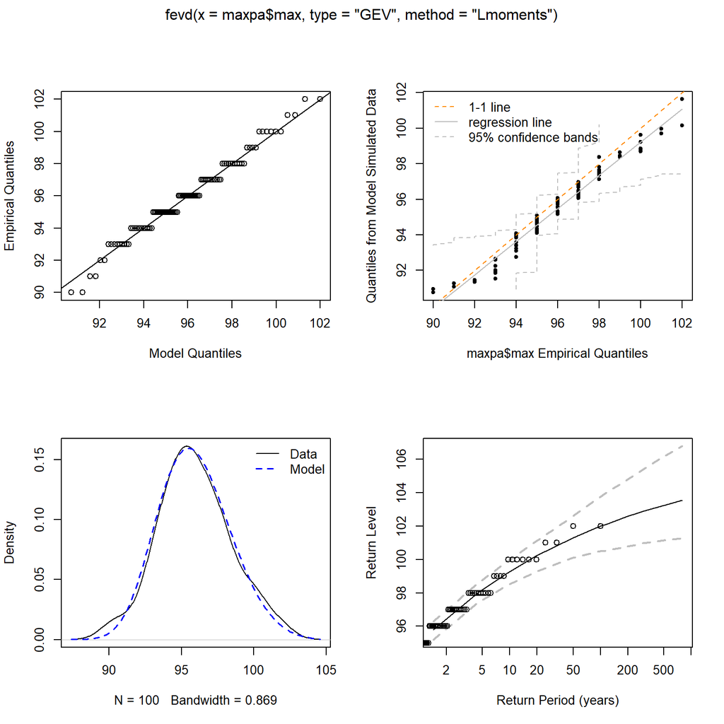

Comme pour la MLE, les graphiques indiquent une bonne modélisation.

La courbe du modèle par la méthode des moments est plus proche des vraies valeurs que la courbe obtenue par MLE. Par contre l’intervalle de confiance par MLE s’élargit moins vite.

### Niveaux de retour GEV

Calculons les niveaux de retour à 200, 400 et 1000 ans pour les 3 méthodes:

```r
return.level(Fit_max_GEV_MLE, return.period = c(200, 400, 1000))
```

```
## fevd(x = maxpa$max, type = "GEV", method = "MLE")
## get(paste("return.level.fevd.", newcl, sep = ""))(x = x, return.period = return.period)
##
##  GEV model fitted to  maxpa$max
## Data are assumed to be  stationary
## [1] "Return Levels for period units in years"
##  200-year level  400-year level 1000-year level
##        102.2425        102.6733        103.1419
```

```r
ci(Fit_max_GEV_MLE,type="return.level",return.period =  c(200, 400, 1000))
```

```
## fevd(x = maxpa$max, type = "GEV", method = "MLE")
##
## [1] "Normal Approx."
##
##                        95% lower CI Estimate 95% upper CI
## 200-year return level      100.7907 102.2425     103.6944
## 400-year return level      100.9911 102.6733     104.3555
## 1000-year return level     101.1614 103.1419     105.1223
```

```r
return.level(Fit_max_GEV_MLE_G, return.period = c(200, 400, 1000))
```

```
## fevd(x = maxpa$max, type = "Gumbel", method = "MLE")
## get(paste("return.level.fevd.", newcl, sep = ""))(x = x, return.period = return.period)
##
##  Gumbel model fitted to  maxpa$max
## Data are assumed to be  stationary
## [1] "Return Levels for period units in years"
##  200-year level  400-year level 1000-year level
##        107.3445        109.0028        111.1929
```

```r
ci(Fit_max_GEV_MLE_G,type="return.level",return.period =  c(200, 400, 1000))
```

```
## fevd(x = maxpa$max, type = "Gumbel", method = "MLE")
##
## [1] "Normal Approx."
##
##                        95% lower CI Estimate 95% upper CI
## 200-year return level      105.3392 107.3445     109.3497
## 400-year return level      106.7693 109.0028     111.2363
## 1000-year return level     108.6563 111.1929     113.7295
```

```r
return.level(Fit_max_GEV_PWM, return.period = c(200, 400, 1000))
```

```
## fevd(x = maxpa$max, type = "GEV", method = "Lmoments")
## get(paste("return.level.fevd.", newcl, sep = ""))(x = x, return.period = return.period)
##
##  GEV model fitted to  maxpa$max
## Data are assumed to be  stationary
## [1] "Return Levels for period units in years"
##  200-year level  400-year level 1000-year level
##        102.5866        103.1028        103.6811
```

```r
ci(Fit_max_GEV_PWM,type="return.level",return.period =  c(200, 400, 1000))
```

```
## fevd(x = maxpa$max, type = "GEV", method = "Lmoments")
##
## [1] "Parametric Bootstrap"
## 502  iterations
##
##               2.5% Estimate    97.5%
## 200-year  100.7500 102.5866 104.6778
## 400-year  100.9843 103.1028 105.7029
## 1000-year 101.2163 103.6811 106.9204
```

On considère en général que le niveau de retour est peu fiable au delà de 4 fois l’étendue temporelle du jeu de données (soit 400 ans, ici).  
Bien que très proches, la modélisation par PWM semble de meilleure qualité avec nos données, c’est celle que nous privilégierions si nous devions prédire la température maximale atteinte en moyenne 1 fois tous les x années.

Nous avons présenté les résultats obtenus par *Gumbel forcé* pour comparaison, tout en considérant cette méthode comme peu adaptée à nos données. Comme prévu, les résultats sont notablement supérieurs.

Notons que les intervalles de confiance restent relativement étroits (nombre d’observations assez important dans notre cas).

### Calculer le point terminal GEV

Le $\gamma$ obtenu par les deux méthodes étant négatif (courbe concave), nous pouvons calculer la limite théorique avec un temps infini selon:$b - \left( \frac{a}{\gamma} \right)$ où **a** est le *scale*, **b** la *location* et $\gamma$ le *shape*.

par MLE:

## Approche par la loi des excés (GPD)

### Choix du seuil

La difficulté est ici de choisir le bon seuil, lequel est déterminant quant à la qualité de la modélisation.  
Effectuer le choix du seuil revient à faire un compromis entre biais variance:

- seuil trop bas (nous sortons de la queue -> biais)
- seuil trop haut (trop peu d’observations -> variance)

L’objectif est aussi de retenir au moins autant de valeurs que par l’approche par *block-maxima*, et idéalement davantage. Nous cherchons donc à prendre le seuil le plus bas possible tout en restant dans le queue de distribution.  
Nous effectuerons ce choix par des méthodes graphiques (*Mean Residual Life plot* et *Threshold Stability plot*).

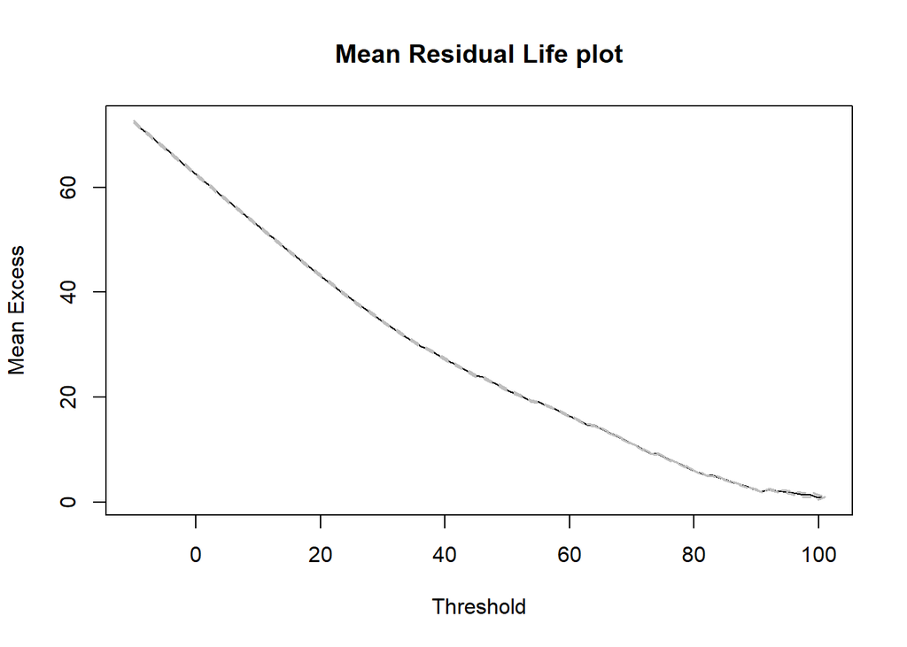

Il n’est pas ici évident de trouver un changement de linéarité.  
En première approche, nous retenons 90°F comme valeur d’inflexion.

```r
length (fc$max [fc$max >90])
```

```
## [1] 1307
```

```r
length (fc$max [fc$max >90])/ length (fc$max)
```

```
## [1] 0.03578469
```

Avec un seuil à 90°F, 1307 observations sont retenues.  
C’est environ 13 fois plus qu’avec la méthode GEV, on peut supposer que nous retenons trop de données et que le modèle aura tendance à sous-estimer les valeurs extrêmes.

Vérifions en modélisant avec ce seuil:

```r
Fit_max_GPD_MLE_90=fevd(fc$max,threshold=90, type="GP",method="MLE",time.units="days")
Fit_max_GPD_MLE_90
```

```
##
## fevd(x = fc$max, threshold = 90, type = "GP", method = "MLE",
##     time.units = "days")
##
## [1] "Estimation Method used: MLE"
##
##
##  Negative Log-Likelihood Value:  2664.559
##
##
##  Estimated parameters:
##     scale     shape
##  3.767730 -0.287588
##
##  Standard Error Estimates:
##      scale      shape
## 0.11398192 0.01459873
##
##  Estimated parameter covariance matrix.
##              scale         shape
## scale  0.012991879 -0.0013933989
## shape -0.001393399  0.0002131228
##
##  AIC = 5333.119
##
##  BIC = 5343.47
```

Le $\gamma$ est inférieur à ceux obrenus par GEV, l’asymptote à la courbe de retour sera donc plus basse.

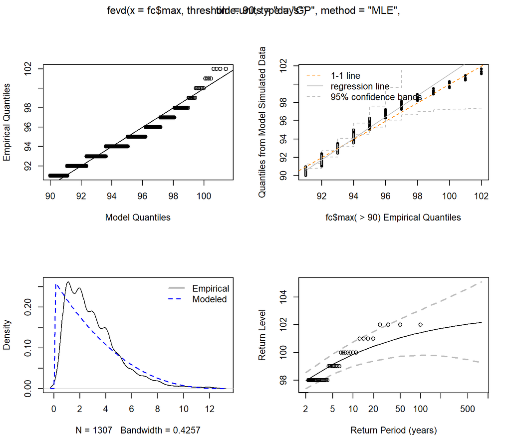

```r
plot (Fit_max_GPD_MLE_90)
```

En effet, la courbe de retour sous-estime les valeurs extrêmes.  
Essayons d’affiner notre choix du seuil.

### Sélection “fine” du seuil

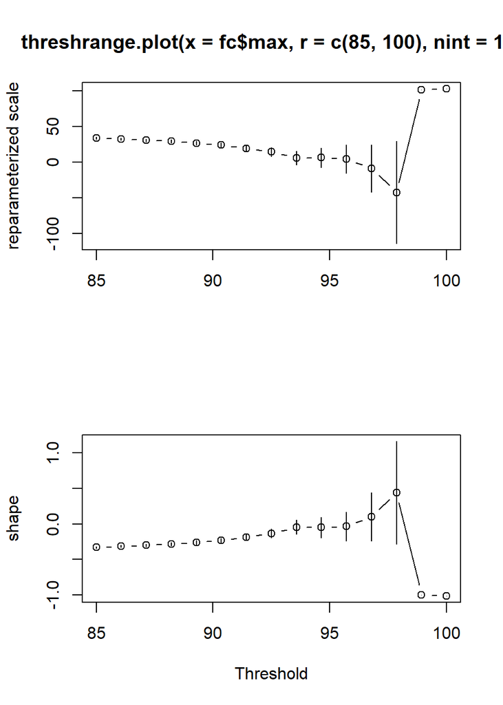

```r
length (fc$max [fc$max >95])
```

```
## [1] 140
```

```r
length (fc$max [fc$max >95])/ length (fc$max)
```

```
## [1] 0.003833096
```

Nous retenons le seuil de 95°F.  
Seulement *140* observations sont retenues à ce seuil, soit moins de *0.4%* du total.  
C’est seulement *40* observations de plus que par la méthode GEV (notons que 100 observations est une valeurs assez confortable pour la GEV, ce qui explique en partie cette faible différence).

```r
Fit_max_GPD_MLE_95 <- fevd(fc$max,threshold=95,type="GP",method="MLE")
Fit_max_GPD_MLE_95
```

```
##
## fevd(x = fc$max, threshold = 95, type = "GP", method = "MLE")
##
## [1] "Estimation Method used: MLE"
##
##
##  Negative Log-Likelihood Value:  245.7897
##
##
##  Estimated parameters:
##     scale     shape
##  3.101921 -0.376381
##
##  Standard Error Estimates:
##      scale      shape
## 0.32310036 0.06869049
##
##  Estimated parameter covariance matrix.
##             scale        shape
## scale  0.10439385 -0.019836363
## shape -0.01983636  0.004718383
##
##  AIC = 495.5794
##
##  BIC = 501.4627
```

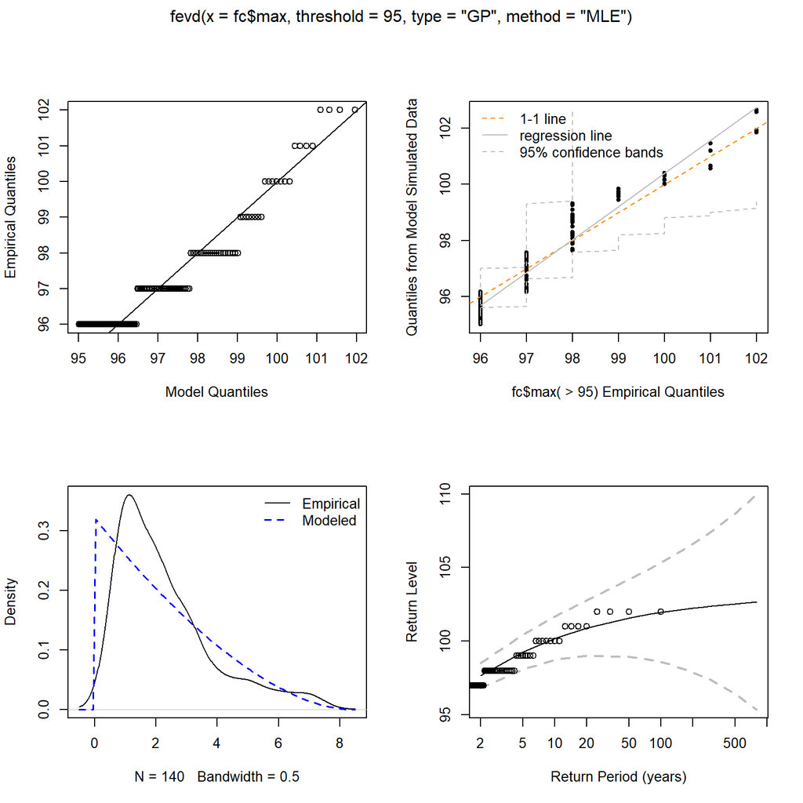

```r
plot (Fit_max_GPD_MLE_95)
```

La modélisation est de bonne qualité.  
Non représenté ici: nous avons essayé d’autres seuils autour de la valeur *90*, *95* semble bien offrir le meilleur compromis.

## GPD méthode des moments pondérés

```r
Fit_max_GPD_PWM_95=fevd(fc$max,threshold=95,type="GP", method="Lmoments")
Fit_max_GPD_PWM_95
```

```
## fevd(x = fc$max, threshold = 95, type = "GP", method = "Lmoments")
## [1] "GP  Fitted to  fc$max  using L-moments estimation."
##      scale      shape
##  4.3592405 -0.9131463
```

Le $\gamma$ est ici notablement inférieur à *-0.5*.  
La méthode des moments ne parait pas adaptées ici.

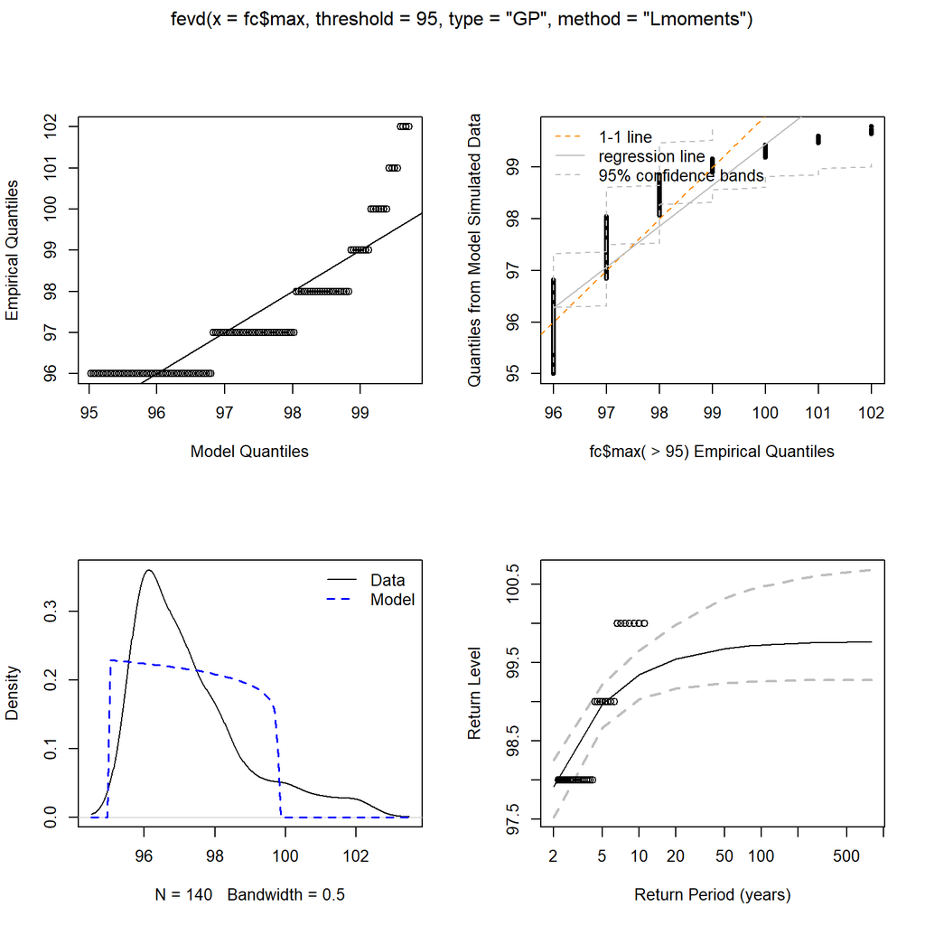

```r
plot (Fit_max_GPD_PWM_95)
```

Les graphiques confirment que la modélisation fonctionne mal.  
Nous avons essayé d’autres valeurs de seuil par la méthode des moments, aucune ne donne de meilleurs résultats.

## Tableau récapitulatif

**Tableau récapitulatif - températures maximales**

| modèle | gamma | prev.à.200.ans | prev.à.400.ans | prev.à.1000.ans | point.terminal |
| --- | --- | --- | --- | --- | --- |
| GEV MLE | -0.242 | 102.2425 | 102.6733 | 103.1419 | 105.0299 |
| GEV MLE (Gumbel) | NA | 107.3445 | 109.0028 | 111.1929 | NA |
| GEV PWM | -0.205 | 102.5866 | 103.1028 | 103.6811 | 106.4813 |
| GPD MLE (95) | -0.376 | 102.2530 | 102.4800 | 102.7021 | 103.2414 |
| GPD PWM (95) | -0.913 | 99.7461 | 99.7591 | 99.7674 | 99.7738 |

## Approche par de-clustering

Nous observons que les jours de fortes températures ne sont pas *idd*. En effet, les fortes chaleurs s’installent le plus souvent plusieurs jours (ne serait-ce que pour des raisons physiques: l’environnement met un certain temps à se réchauffer en accumulant de la chaleur et met aussi un certain temps à se refroidir).  
Cette limite théorique n’est pas un problème dans le cas de la GEV par block-maxima annuel, mais la non indépendance entre les observations peut fausser les modèles dans le cas de la GPD.

Une solution consiste à réunir les observations en *cluster* et ne retenir que la valeur maximale de chaque *cluster*. L’argument *r* définit le nombre de *clustes* ainsi:  
r=0, aucun *cluster*, pas de modification des données;  
r=1, (peu discriminant) deux *clusters* différents sont créés quand une seule valeur sépare deux observations au-dessus du seuil;  
r=2, deux *clusters* différents sont créés quand une ou deux valeurs séparent deux observations au-dessus du seuil, etc.

Donc, plus la valeur de *r* est élevée, plus le nombre d’observations écartées est grand.  
Exemple de de-clustering avec r=1 et r=10 sur les données **max**:

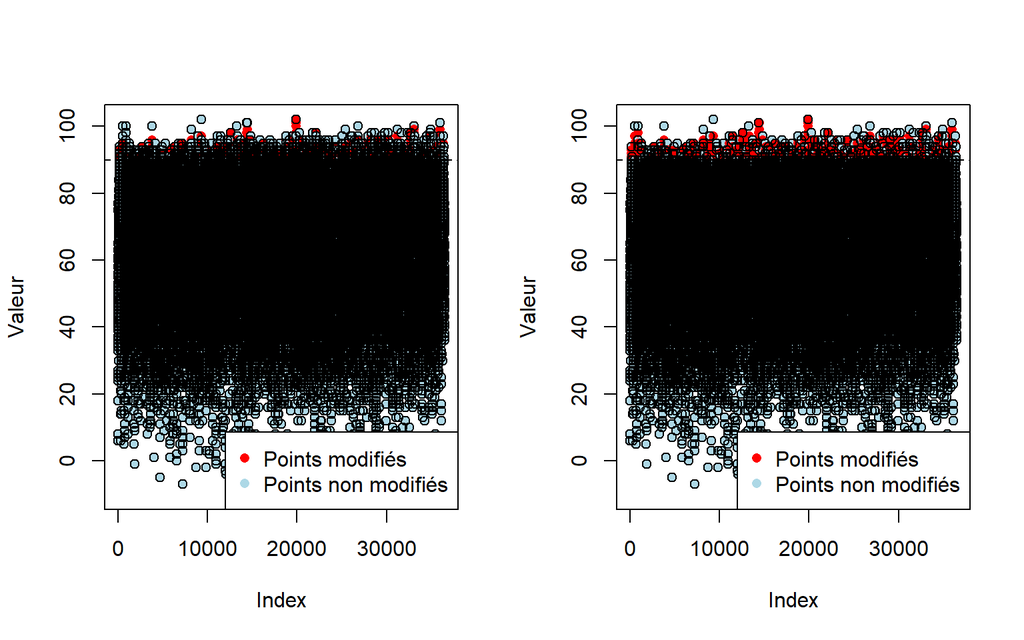

```r
par(mfrow = c(1, 2))
# r=1
fc$fcclus_1 <- decluster(fc$max, threshold = 90, r = 1, replace.with = 89)
# Identifier les points modifiés
mod_points <- fc$max != fc$fcclus_1
plot(fc$fcclus_1, col = ifelse(mod_points, "red", "lightblue"), pch = 16,
     main = "r=1",
     xlab = "Index", ylab = "Valeur")
legend("bottomright", legend = c("Points modifiés", "Points non modifiés"),
       col = c("red", "lightblue"), pch = 16)

# r=10
fc$fcclus_10 <- decluster(fc$max, threshold = 90, r = 10, replace.with = 89)
# Identifier les points modifiés
mod_points <- fc$max != fc$fcclus_10
plot(fc$fcclus_10, col = ifelse(mod_points, "red", "lightblue"), pch = 16,
     main = "r=10",
     xlab = "Index", ylab = "Valeur")
legend("bottomright", legend = c("Points modifiés", "Points non modifiés"),
       col = c("red", "lightblue"), pch = 16)
```

La difficulté est de choisir la meilleure valeur de *r*.  
Nous faisons nos essais avec une valeur de seuil à 90°F plutôt qu’95°F, afin d’augmenter le nombre d’observations.  
Nous transformons les valeurs au dessus du seuil (*90*) à une valeur sous le seuil (*89*) qui seront exclues de la modélisation.  
Essayons plusieurs valeurs de r:

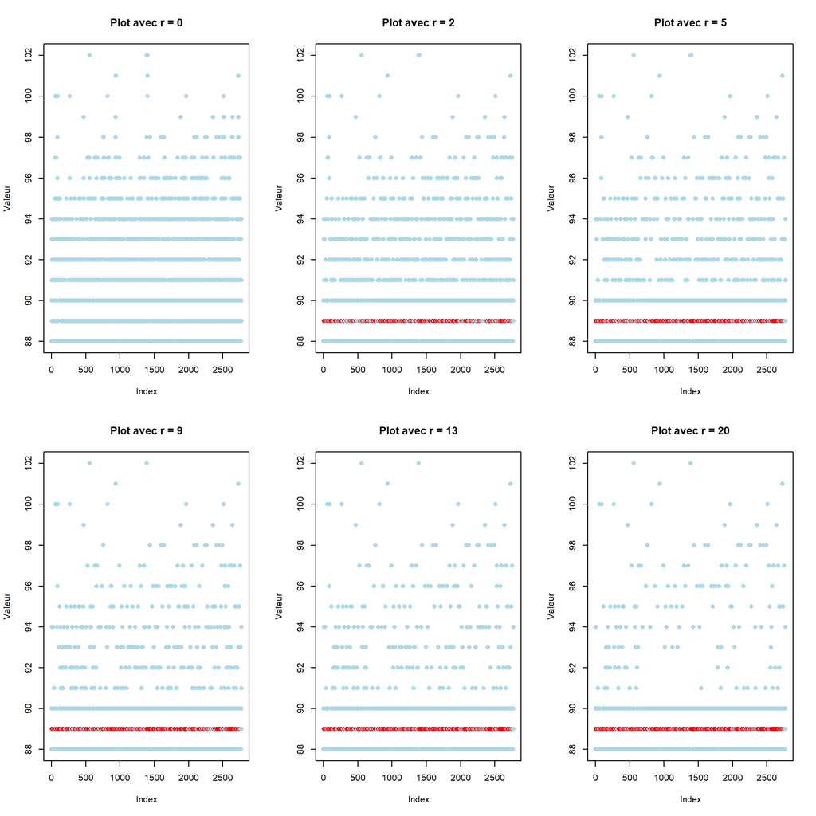

```r
par(mfrow = c(2, 3))
# vecteurs des valeurs de r
r_values <- c(0, 2, 5, 9, 13, 20)

# Boucle pour générer les graphiques avec différentes valeurs de r
for (r in r_values) {
  fc$fcclus <- decluster(fc$max, threshold = 90, r = r, replace.with = 89)

  # Identifier les points modifiés
  mod_points <- fc$max != fc$fcclus

  # Définir le seuil d'affichage du graphiqeu
  threshold <- 87

  # Filtre les points au-dessus du seuil
  above_threshold <- fc$fcclus > threshold

  # Trace les points au-dessus du seuil
  plot(fc$fcclus[above_threshold], col = ifelse(mod_points[above_threshold], "red", "lightblue"), pch = 16,
       main = paste("Plot avec r =", r),
       xlab = "Index", ylab = "Valeur")
}
```

Nous retenons la valeur de r=9 (compromis entre l’indépendance des observations et la nécessité d’en garder un nombre suffisant).

```r
fc$fcclus <- decluster(fc$max, threshold = 90, r=9, replace.with=89)
Fit_max_GPD_MLE_90_clus=fevd(fc$fcclus,threshold=90, type="GP",method="MLE",time.units="days")
Fit_max_GPD_MLE_90_clus
```

```
##
## fevd(x = fc$fcclus, threshold = 90, type = "GP", method = "MLE",
##     time.units = "days")
##
## [1] "Estimation Method used: MLE"
##
##
##  Negative Log-Likelihood Value:  665.032
##
##
##  Estimated parameters:
##      scale      shape
##  5.3481430 -0.4225707
##
##  Standard Error Estimates:
##      scale      shape
## 0.34243550 0.03630577
##
##  Estimated parameter covariance matrix.
##             scale        shape
## scale  0.11726207 -0.011464208
## shape -0.01146421  0.001318109
##
##  AIC = 1334.064
##
##  BIC = 1341.438
```

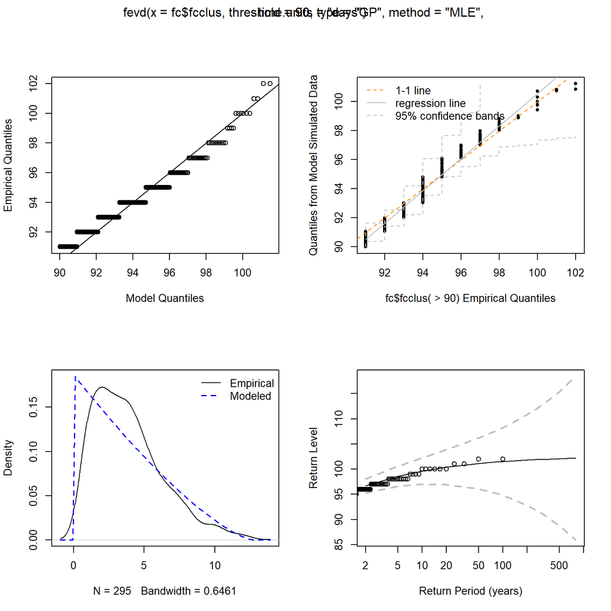

```r
plot (Fit_max_GPD_MLE_90_clus)
```

Les graphiques indiquent une bonne modélisation (meillleur que sans le *de-clustering* avec le même seuil).  
Notons que le $\gamma$ est inférieur, le point terminal sera donc plus bas.  
Nous ne poussons pas plus loin les essais avec cette méthode, mais nous avons pu en constater le potentiel.

# Temperatures minimales

Dans la partie précédente, nous avons modélisé des données dont la distribution avait une queue courte à droite.  
Afin de comparer ce que donnerait la même approche (sur le même jeu de données) avec une distribution ayant une queue plus longue, nous nous intéressons maintenant aux minimums de la variable **MnT**.

C’est aussi l’occasion de traiter le cas où l’on cherche des valeurs extrêmes minimales. Pour cela, créons une variable **min** dans notre dataframe **fc**, en changeant le signe de la variable **MnT** du dataframe original.

```r
fc <- fc %>%  mutate(min= -FCwx$MnT) # ajout de la variable min avec changement de signe
summary (fc$min)
```

```
##    Min. 1st Qu.  Median    Mean 3rd Qu.    Max.
##  -70.00  -48.00  -34.00  -33.92  -22.00   41.00
```

La temperature la plus basse atteinte sur les 100 ans est de -41°F.

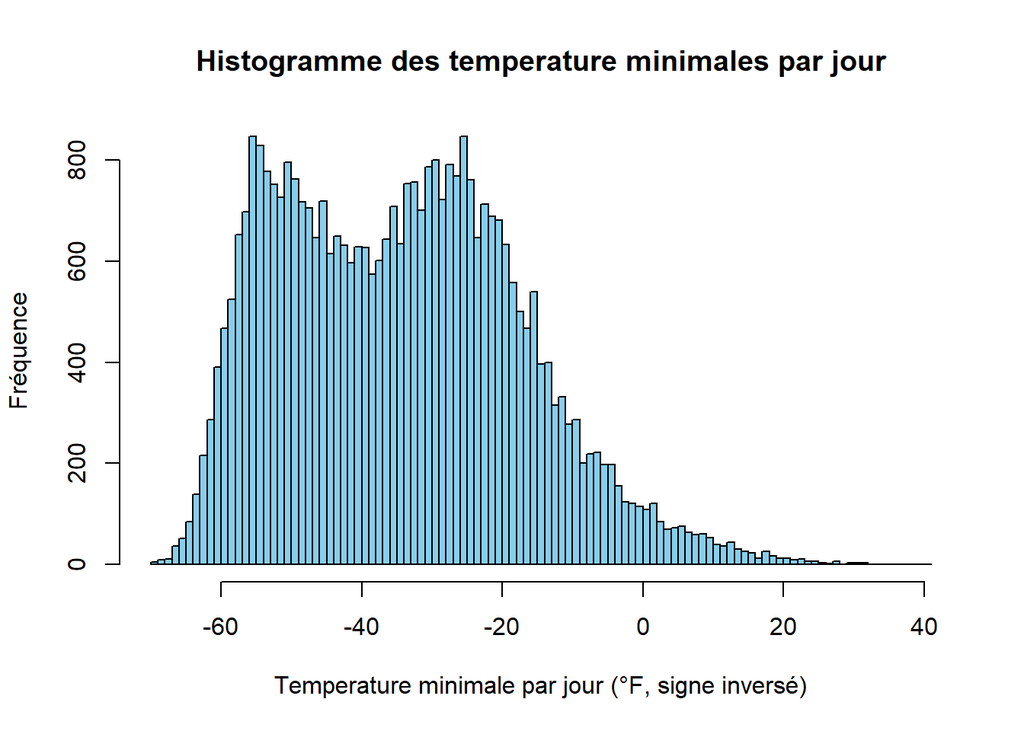

Cette fois la distribution montre une asymétrie positive (ou *skewness positive*), confirmée par une moyenne supérieure à la médiane. La queue de la distribution est plus légère et moins courte que pour les valeurs maximales.

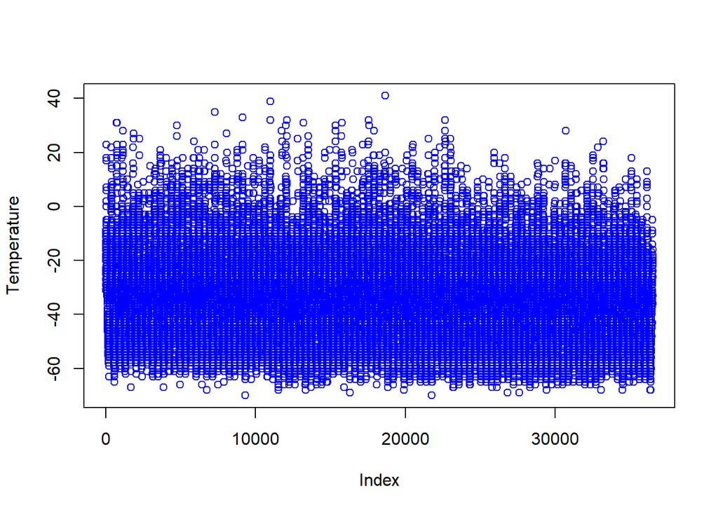

Le graphique confirme bien que la variance dans les valeurs extrêmes est beaucoup plus forte que dans le cas des températures maximales.

## GEV

Retenons uniquement la valeur maximale de chaque année dans le dataframe **minpa** (minimum par année):

```r
minpa<- blockmaxxer(fc, blocks = fc$Year, which="min")
summary (minpa$min)
```

```
##    Min. 1st Qu.  Median    Mean 3rd Qu.    Max.
##   -5.00   10.75   17.00   17.66   24.00   41.00
```

Les 100 valeurs minimales retenues s’étalent de +5°F à -41°F

### GEV MLE

```r
Fit_min_GEV_MLE <- fevd(minpa$min,type="GEV",method="MLE")
Fit_min_GEV_MLE
```

```
##
## fevd(x = minpa$min, type = "GEV", method = "MLE")
##
## [1] "Estimation Method used: MLE"
##
##
##  Negative Log-Likelihood Value:  361.3859
##
##
##  Estimated parameters:
##  location     scale     shape
## 14.243744  8.699548 -0.227254
##
##  Standard Error Estimates:
##  location     scale     shape
## 0.9651821 0.6814811 0.0671599
##
##  Estimated parameter covariance matrix.
##             location       scale        shape
## location  0.93157649  0.06700770 -0.024880815
## scale     0.06700770  0.46441644 -0.024264742
## shape    -0.02488082 -0.02426474  0.004510452
##
##  AIC = 728.7717
##
##  BIC = 736.5873
```

```r
ci(Fit_min_GEV_MLE,type="parameter")                   # IC à 95%
```

```
## fevd(x = minpa$min, type = "GEV", method = "MLE")
##
## [1] "Normal Approx."
##
##          95% lower CI  Estimate 95% upper CI
## location    12.352021 14.243744  16.13546578
## scale        7.363870  8.699548  10.03522650
## shape       -0.358885 -0.227254  -0.09562306
```

```r
ci(Fit_min_GEV_MLE,type="parameter", alpha=0.01)           # IC à 99%
```

```
## fevd(x = minpa$min, type = "GEV", method = "MLE")
##
## [1] "Normal Approx."
##
##          99% lower CI  Estimate 99% upper CI
## location   11.7575993 14.243744  16.72988796
## scale       6.9441693  8.699548  10.45492705
## shape      -0.4002465 -0.227254  -0.05426161
```

le $\gamma$ est ici aussi négatif: -0.227254 (contre -0.2417402 pour les températures maximales, la différence est mineure). Autrement dit, bien que la distribution à droite soit beaucoup plus fine, cela ne suffit pas à priori à nous “sortir” du domaine d’attraction de Welbull.  
Les intervalles de confiance de $\gamma$, y compris à 99%, restent aussi dans le négatif (cependant plus proche de zéro que pour les valeurs max).

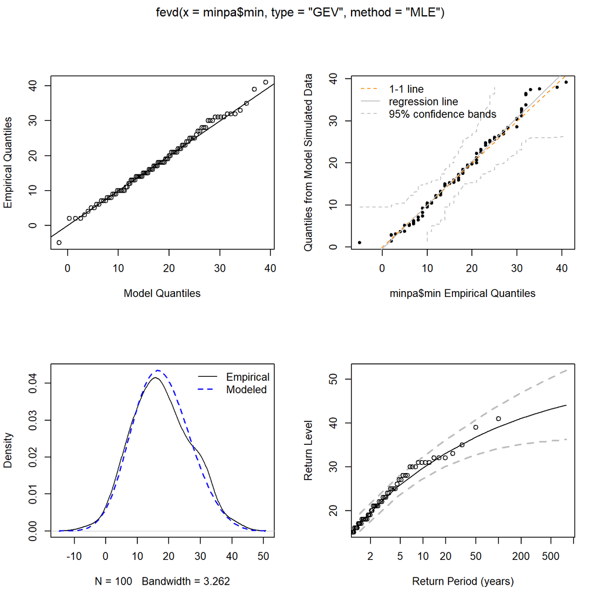

La modélisation par MLE est de bonne qualité.

Une modélisation en forçant *Gumbel* devrait sans doute donner de meilleurs résultat que pour la modélisation des températures maximales par jour.

```r
Fit_min_GEV_MLE_G <- fevd(minpa$min,  type="Gumbel",method="MLE")
Fit_min_GEV_MLE_G
```

```
##
## fevd(x = minpa$min, type = "Gumbel", method = "MLE")
##
## [1] "Estimation Method used: MLE"
##
##
##  Negative Log-Likelihood Value:  365.7439
##
##
##  Estimated parameters:
##  location     scale
## 13.224401  8.420671
##
##  Standard Error Estimates:
##  location     scale
## 0.8916226 0.6193689
##
##  Estimated parameter covariance matrix.
##           location     scale
## location 0.7949908 0.1815424
## scale    0.1815424 0.3836179
##
##  AIC = 735.4879
##
##  BIC = 740.6982
```

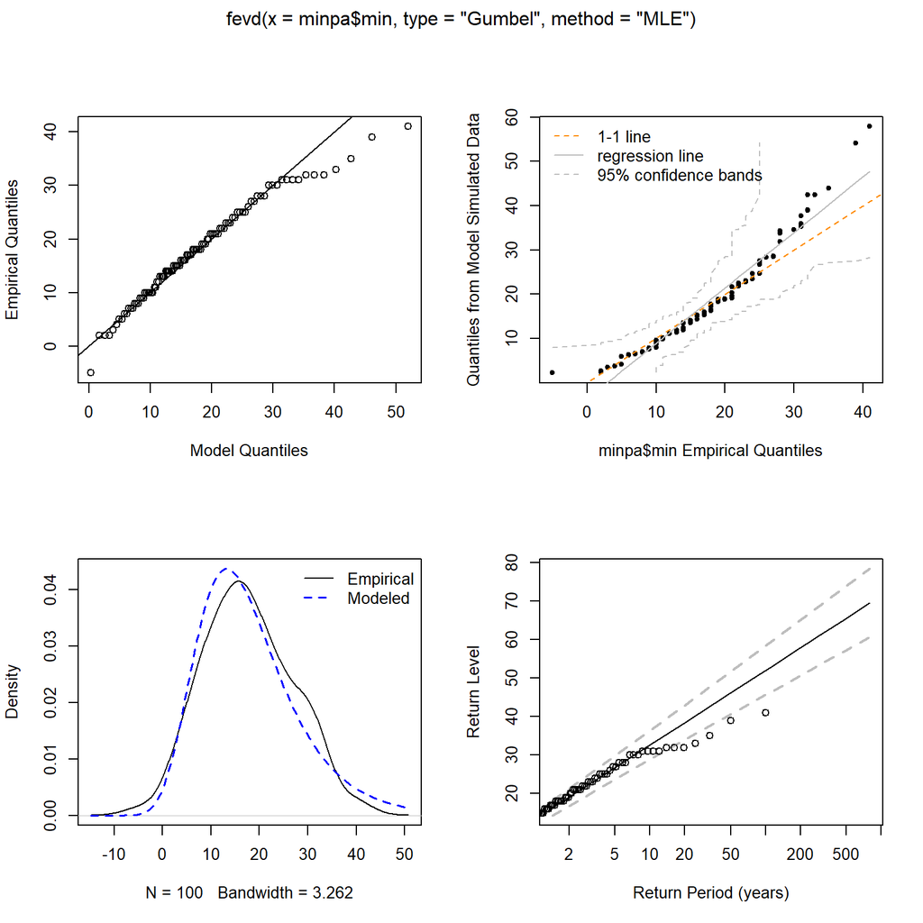

Là encore, *Gumbel* à tendance à surestimer les valeurs extrêmes.  
La loi de *Weibul* reste plus adaptée.

### GEV PWM

```r
Fit_min_GEV_PWM <- fevd(minpa$min,type="GEV",method="Lmoments")
Fit_min_GEV_PWM
```

```
## fevd(x = minpa$min, type = "GEV", method = "Lmoments")
## [1] "GEV  Fitted to  minpa$min  using L-moments estimation."
##   location      scale      shape
## 14.0748041  8.7172203 -0.1970552
```

```r
ci(Fit_min_GEV_PWM,type="parameter")           # IC à 95%
```

```
## fevd(x = minpa$min, type = "GEV", method = "Lmoments")
##
## [1] "Parametric Bootstrap"
## 502  iterations
##
##                2.5%   Estimate       97.5%
## location 12.1993816 14.0748041 16.03602749
## scale     7.4081329  8.7172203  9.97794075
## shape    -0.3316235 -0.1970552 -0.06239328
```

```r
ci(Fit_min_GEV_PWM,type="parameter", alpha=0.01) # IC à 99%
```

```
## fevd(x = minpa$min, type = "GEV", method = "Lmoments")
##
## [1] "Parametric Bootstrap"
## 502  iterations
##
##                0.5%   Estimate       99.5%
## location 11.7039561 14.0748041 17.30251974
## scale     7.2739805  8.7172203 10.65291825
## shape    -0.4122114 -0.1970552 -0.03318917
```

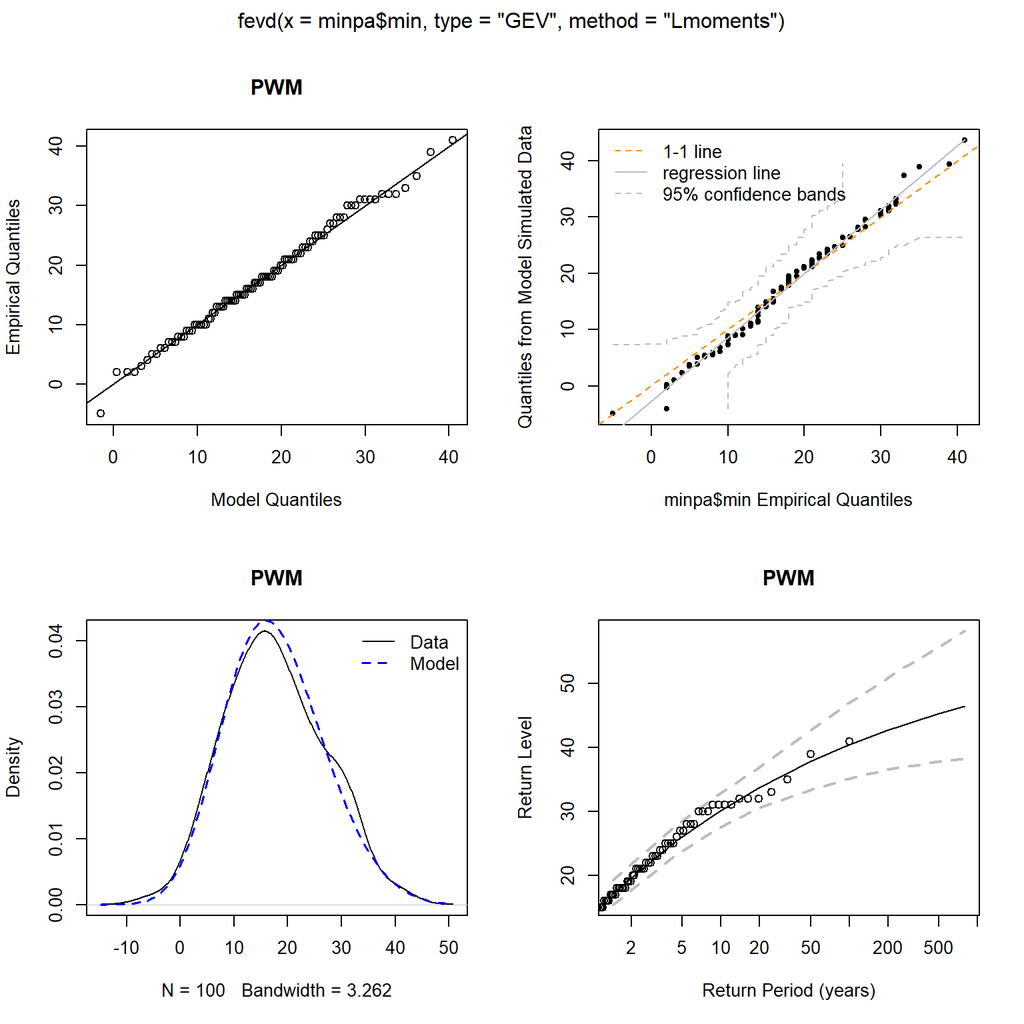

La courbe du modèle par la méthode des moments semble mieux adaptée que la MLE pour les grandes valeurs, les intervalles de confiance sont comparables (l’IC s’élargit un peu plus dans le cas des moments cependant).

## GPD

### Selection du seuil

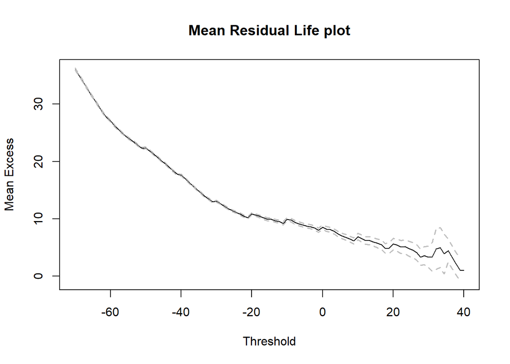

Là non plus, il n’est pas aisé de déterminer le point d’inflexion.  
La valeur de *+20°F* (-20 sur le graphique) semble indiquer une rupture de linéarité, mais cette valeur ne situe pas (assez) dans la queue de distribution.  
Étudions plus précieusement le comportement entre les valeurs *-20°F* (+20 sur le graphique) afin d’affiner notre choix:

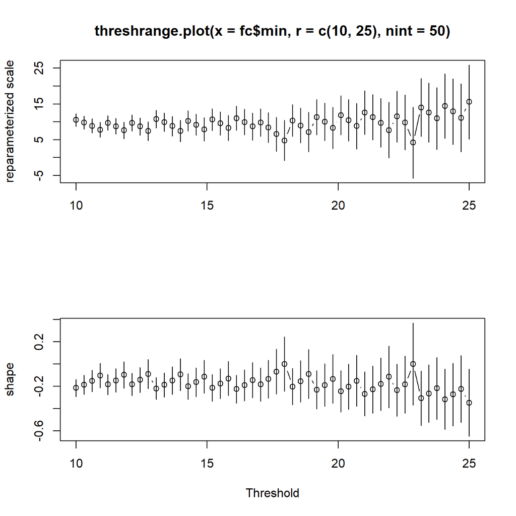

Nous retenons la valeur de *17* (-17°F) pour notre modélisation:

```r
length (fc$min [fc$min >17])
```

```
## [1] 129
```

```r
length (fc$min [fc$min >17])/ length (fc$max)
```

```
## [1] 0.003531924
```

```r
Fit_min_GPD_MLE_17 <- fevd(fc$min,threshold=17, type="GP",method="MLE",time.units="days")
Fit_min_GPD_MLE_17
```

```
##
## fevd(x = fc$min, threshold = 17, type = "GP", method = "MLE",
##     time.units = "days")
##
## [1] "Estimation Method used: MLE"
##
##
##  Negative Log-Likelihood Value:  350.3318
##
##
##  Estimated parameters:
##      scale      shape
##  6.7202270 -0.1893747
##
##  Standard Error Estimates:
##      scale      shape
## 0.77125805 0.07547932
##
##  Estimated parameter covariance matrix.
##             scale        shape
## scale  0.59483897 -0.046284026
## shape -0.04628403  0.005697127
##
##  AIC = 704.6636
##
##  BIC = 710.3832
```

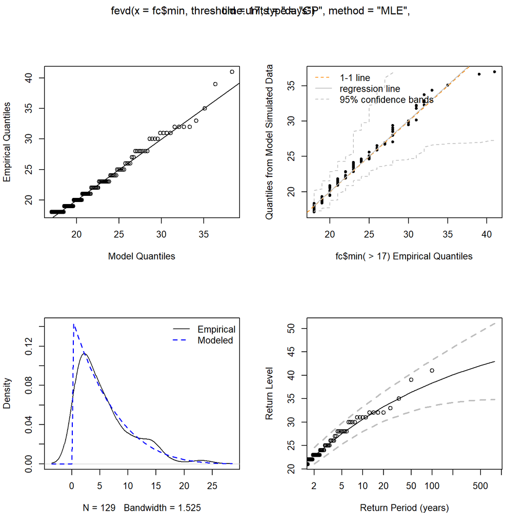

```r
plot (Fit_min_GPD_MLE_17)
```

Le résultat est acceptable mais semble cependant moins bon qu’avec la MLE.  
Nous avons essayé par tâtonnement d’autres valeurs de seuil mais sans obtenir de meilleurs résultat.

```r
Fit_min_GPD_PWM_17=fevd(fc$max,threshold=17,type="GP", method="Lmoments")
Fit_min_GPD_PWM_17
```

```
## fevd(x = fc$max, threshold = 17, type = "GP", method = "Lmoments")
## [1] "GP  Fitted to  fc$max  using L-moments estimation."
##     scale     shape
## 157.65300  -2.42891
```

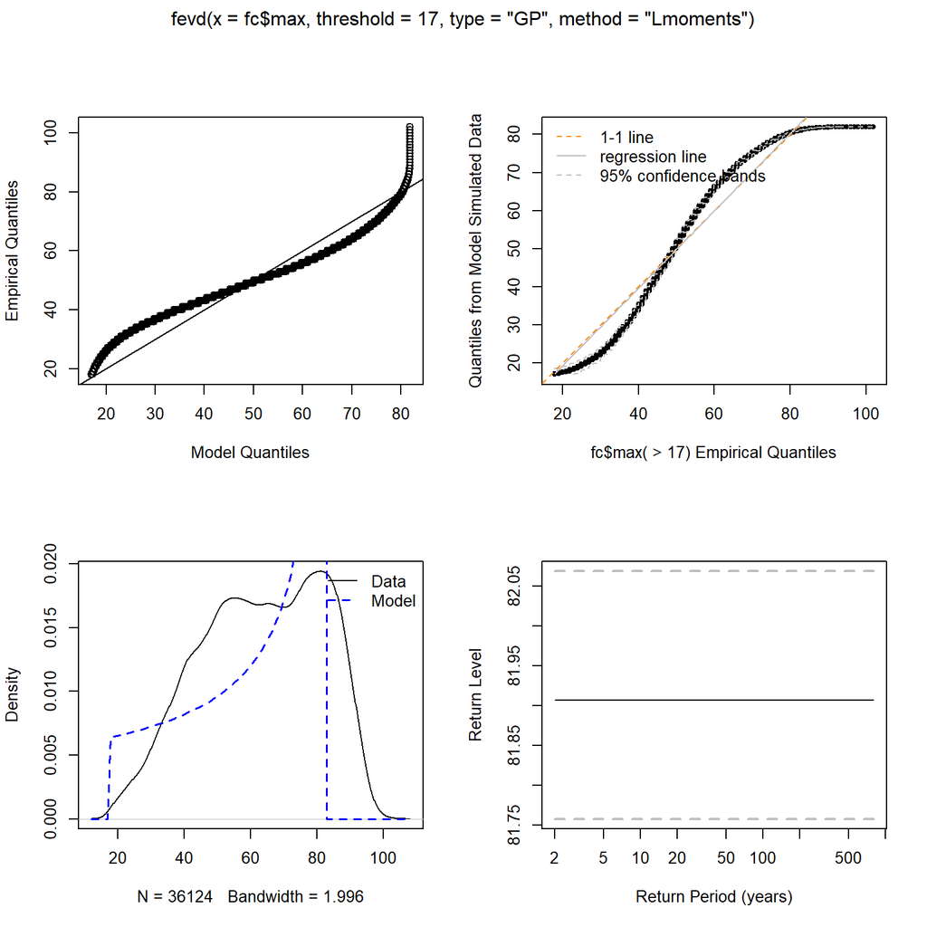

```r
plot (Fit_min_GPD_PWM_17)
```

## Tableau récapitulatif

Tableau récapitulatif - temperatures minimales (signe inversé)

[output not shown]

# Conclusion